# Chapter 8 Applied Exercises

To start with a clean session, we first remove all packages except the base R packages (we will load anything needed later) and all variables.

```r
rm(list = ls())
pkgs = names(sessionInfo()$otherPkgs)
if (!is.null(pkgs)) {
  detach_list <- paste0("package:", pkgs)
  lapply(detach_list, FUN = detach, character.only = TRUE)
}
```

# Exercise 3

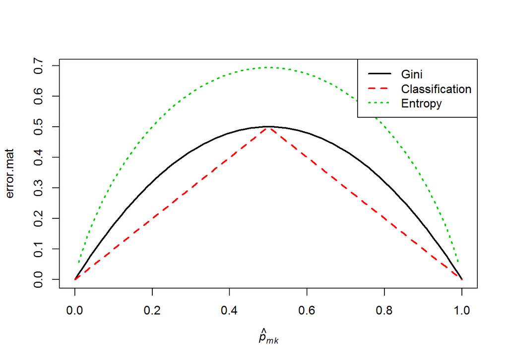

```r
p = seq(0,1, length = 100)
# Gini Index
gini= 2*p*(1-p)
err = apply(cbind(1-p, p), FUN = min, MARGIN = 1)
entropy = -p*log(p) - (1-p)*log(1-p)
error.mat = cbind(gini, err, entropy)
matplot(p, error.mat, xlab = expression(italic(hat(p)[mk])), type = "l", lwd = 2, col = 1:3, lty = 1:3)
legend("topright", legend = c("Gini", "Classification", "Entropy"), lwd = 2, col = 1:3, lty = 1:3)
```

To see how to write mathematical expressions on a plot, type `?plotmath`. Pairwise minimum command `pmin` could be used above instead of the `apply()` function.

# Exercise 7

To see not only how changes in the number of trees and $m$ affect the test error, but also how they interact, we depict them on the same plot. We find the test MSE as a function of the number of trees for values $m = p, p/2, \sqrt{p}$.

```r
library(randomForest)
library(MASS)
# define test and train
set.seed(1)
train = sample(1:nrow(Boston), size = nrow(Boston)/2)
test = -train
test.y = Boston$medv[test]
# Grids for ntree and mtry
(ntree_seq = seq(1, 1000, by = 20))
```

```
##  [1]   1  21  41  61  81 101 121 141 161 181 201 221 241 261 281 301 321
## [18] 341 361 381 401 421 441 461 481 501 521 541 561 581 601 621 641 661
## [35] 681 701 721 741 761 781 801 821 841 861 881 901 921 941 961 981
```

```r
(mtry_seq = c(13, round(13/2), round(sqrt(13))))
```

```
## [1] 13  6  4
```

```r
err_mat = matrix(NA, nrow = length(ntree_seq), ncol = length(mtry_seq),
                 dimnames = list(NULL, NULL))
# error estimates for the grid
for (i_tree in 1:length(ntree_seq)) {
  for (j_mtry in 1:length(mtry_seq)) {
    rf_boston = randomForest(medv ~ ., data = Boston, ntree = ntree_seq[i_tree],
                               mtry = mtry_seq[j_mtry], subset = train)
    rf_pred = predict(rf_boston, newdata = Boston[test, ])
    err_mat[i_tree, j_mtry] = mean((rf_pred - test.y)^2)
  }
}
```

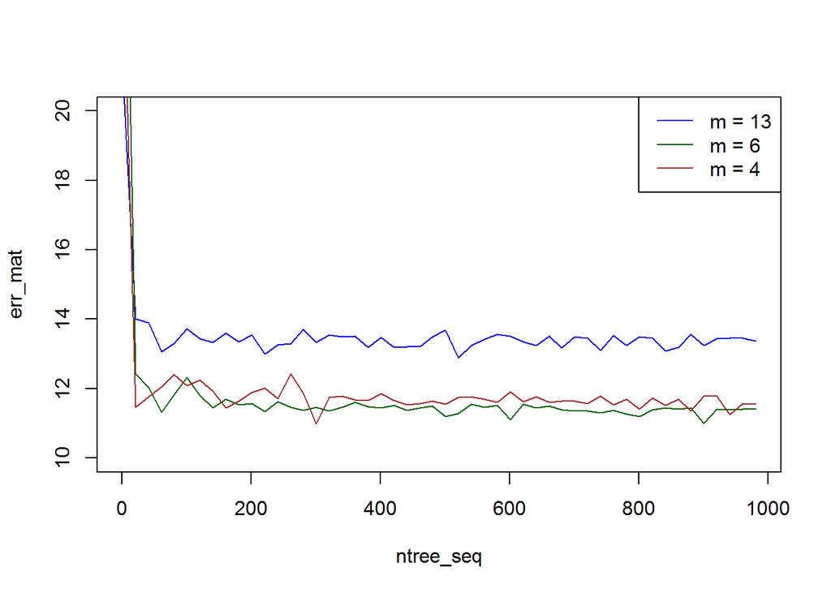

```r
matplot(ntree_seq, err_mat, type = "l", lty = 1, col = c("blue", "darkgreen", "brown"), lwd = 1, ylim = c(10,20))
legend("topright", legend = paste0("m = ", mtry_seq), col = c("blue", "darkgreen", "brown"), lwd = 1)
```

Using 400 trees is sufficient to give good performance and $m \simeq p/2= 6$ leads to the best test MSE. Random forest outperforms bagging in this example.

# Exercise 8

## Part 8.a)

We will predict `Sales` in the `Carseats` data, treating it as a quantitative variable.

```r
library(ISLR)
library(tree)
# split the data
set.seed(1)
train = sample(1:nrow(Carseats), size = nrow(Carseats)/2)
test = -train
test.y = Carseats$Sales[test]
```

## Part 8.b)

```r
# fit regression tree
tree.carseats = tree(Sales ~ ., data = Carseats, subset = train)
tree.carseats
```

```
## node), split, n, deviance, yval
##       * denotes terminal node
##
##  1) root 200 1526.000  7.335
##    2) ShelveLoc: Bad,Medium 164 1084.000  6.815
##      4) Price < 120.5 103  541.000  7.776
##        8) Age < 50.5 39  133.100  9.278
##         16) Price < 104.5 25   83.050  9.808
##           32) ShelveLoc: Bad 7   22.340  8.284 *
##           33) ShelveLoc: Medium 18   38.140 10.400 *
##         17) Price > 104.5 14   30.510  8.333
##           34) Advertising < 3.5 5    6.584  6.922 *
##           35) Advertising > 3.5 9    8.444  9.117 *
##        9) Age > 50.5 64  266.200  6.860
##         18) Price < 92 17   67.560  8.628
##           36) Income < 85 9   23.830  7.512 *
##           37) Income > 85 8   19.940  9.882 *
##         19) Price > 92 47  126.300  6.221
##           38) ShelveLoc: Bad 16   29.890  5.059 *
##           39) ShelveLoc: Medium 31   63.660  6.820
##             78) CompPrice < 107 5    4.229  5.206 *
##             79) CompPrice > 107 26   43.900  7.131 *
##      5) Price > 120.5 61  287.000  5.192
##       10) Age < 66.5 49  181.400  5.654
##         20) CompPrice < 148 37  129.600  5.208
##           40) Advertising < 10.5 25   75.180  4.627 *
##           41) Advertising > 10.5 12   28.370  6.418 *
##         21) CompPrice > 148 12   21.680  7.031 *
##       11) Age > 66.5 12   52.410  3.303
##         22) Price < 132 5   16.300  4.780 *
##         23) Price > 132 7   17.410  2.249 *
##    3) ShelveLoc: Good 36  196.000  9.706
##      6) Price < 113 10   19.960 12.080 *
##      7) Price > 113 26   97.810  8.792
##       14) Price < 142.5 20   54.100  9.337
##         28) CompPrice < 133 15   24.220  8.778 *
##         29) CompPrice > 133 5   11.130 11.010 *
##       15) Price > 142.5 6   17.930  6.973 *
```

What if we use Gini index for growing the tree?

```r
tree.carseats_gini = tree(Sales ~ ., data = Carseats, subset = train, split = "gini")
tree.carseats_gini
```

```
## node), split, n, deviance, yval
##       * denotes terminal node
##
## 1) root 200 1526 7.335 *
```

It leads to no partitioning! Hence, it seems best to use other packages such as `rpart` for splitting according to the Gini index. It is also not clear to me the default splitting accroding to deviance is equivalent to cross-entropy. A little algebra shows that deviance contribution of each region $R_m$ should be normalized by $n_m$ to become equivalent to cross-entropy.  
As a result of these points, although the package `tree` could be a strating point, it is not my choice for final results in a regression tree. However, we continue to use the package `tree` and the default for its argument `split` which is `deviance`.

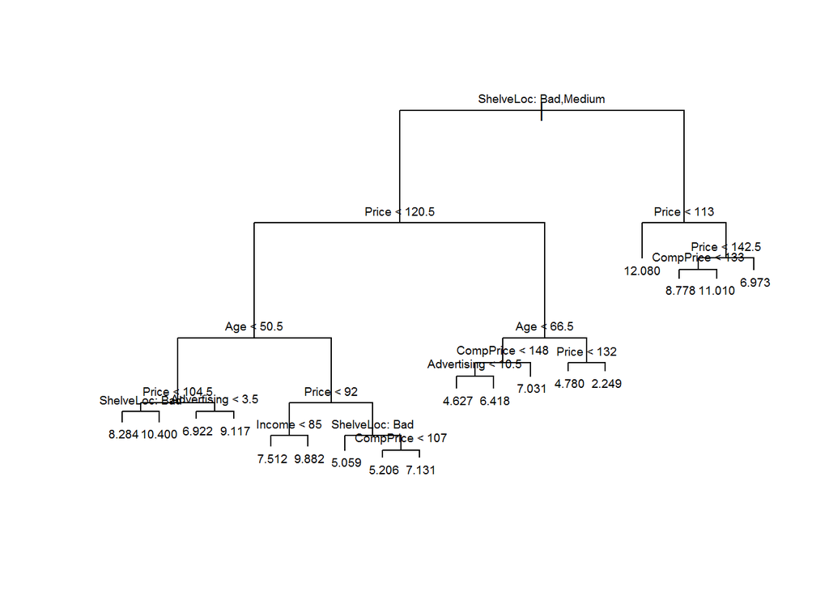

```r
# plot the tree
plot(tree.carseats)
text(tree.carseats, pretty = FALSE, cex = 0.6)
```

```r
#
```

Similar to the classification tree considered in the chapter’s lab, shelving location seems to be the most important variable. The first branch differentiates the `Good` locations from `Medium` and `Bad` locations. Price also appears to be important, as many branches distinguish levels of price.

```r
# predict for test observations
tree_preds = predict(tree.carseats, newdata = Carseats[test, ])
# test MSE:
mse_tree = mean((tree_preds - test.y)^2)
mse_tree
```

```
## [1] 4.148897
```

## Part 8.c)

Now we prune the tree to see whether we can improve prediction accuracy.

```r
set.seed(1)
cv_carseats = cv.tree(tree.carseats)
cv_carseats
```

```
## $size
##  [1] 18 17 16 15 14 12 11 10  9  8  7  6  5  4  3  1
##
## $dev
##  [1] 1127.510 1163.270 1163.270 1169.097 1169.097 1153.636 1129.237
##  [8] 1139.639 1139.232 1109.839 1135.897 1126.203 1218.821 1205.007
## [15] 1331.927 1612.664
##
## $k
##  [1]      -Inf  15.48181  15.53599  18.69038  18.74886  21.05038  23.79480
##  [8]  25.78579  26.01210  30.10435  32.74801  53.28569  72.33061  78.19599
## [15] 141.73781 251.22901
##
## $method
## [1] "deviance"
##
## attr(,"class")
## [1] "prune"         "tree.sequence"
```

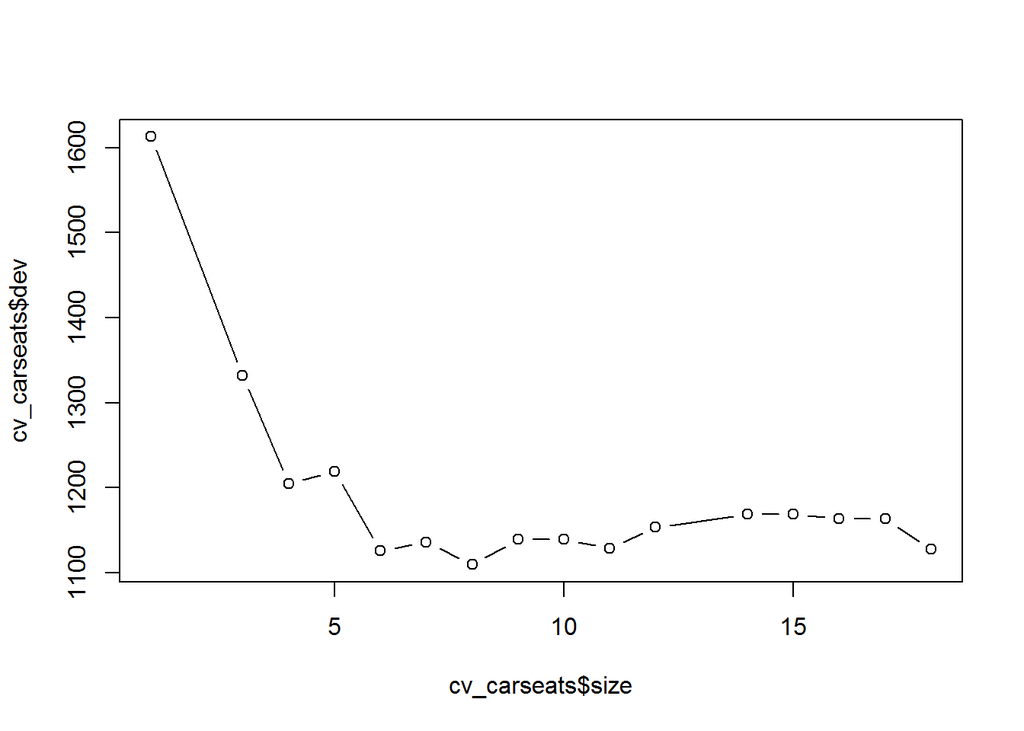

```r
plot(cv_carseats$size, cv_carseats$dev, type = "b")
```

The cross-validation MSE estimates is minimized for 8 splits.

```r
# find the pruned tree
prune_carseats = prune.tree(tree.carseats, best = 8)
# predict for the pruned tree
prune_preds = predict(prune_carseats, newdata = Carseats[test, ])
# test mse for the pruned tree
mse_prune_carseats = mean((prune_preds - test.y)^2)
mse_prune_carseats
```

```
## [1] 5.09085
```

It results in larger test MSE, so seems not to improve accuracy (for this specific test set).

## Exercise 8.d)

```r
library(randomForest)
set.seed(1)
bag_carseats = randomForest(Sales ~ ., data = Carseats, subset = train,
                            mtry = ncol(Carseats)-1, ntree = 500, importance = TRUE)
preds_bag_carseats = predict(bag_carseats, newdata = Carseats[test, ])
mse_bag_carseats = mean((preds_bag_carseats - test.y)^2)
mse_bag_carseats
```

```
## [1] 2.554292
```

Using bagging would improve the prediciton accuracy.  
Note that we set `mtry` equal to number of all the predictors, which is supposed to give us the bagging estimator, which is a special case of random forest estimator. However, it appears that doing so would not exactly result in a bagging estimator, as introduced in the textbook. We would expect the baggin estimator to be certain, since there is no randomness when all predictors are considered in each split. However, it appears that the algorithm for `randomForest` generates other sources of randomness. That is why we have set the seed in the code chunk above.  
If we do not set the random seed, we would get different results each time we we use `randomForest()` even for maximum value of `mtry` and `ntree` being equal to one.  
Now we determine which variables are most important:

```r
importance(bag_carseats)
```

```
##               %IncMSE IncNodePurity
## CompPrice   14.032030    129.568747
## Income       5.523038     75.448682
## Advertising 13.571285    131.246840
## Population   1.968853     63.042648
## Price       56.863812    504.158108
## ShelveLoc   44.720455    323.055042
## Age         22.225468    194.915976
## Education    4.823966     40.810991
## Urban       -1.902185      8.746566
## US           6.632887     14.599565
```

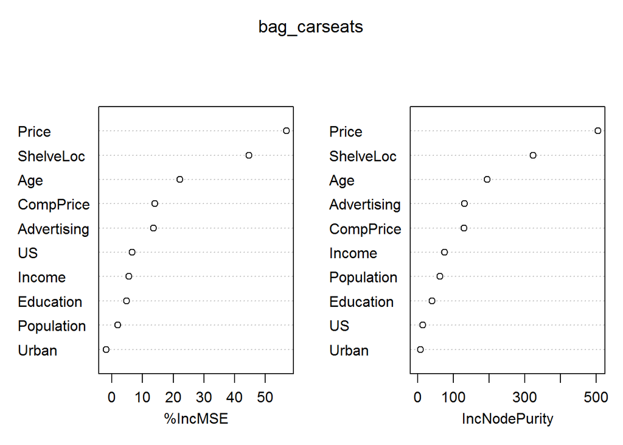

```r
varImpPlot(bag_carseats)
```

The variables `Price` and ShelveLoc`appear to be the most important variables according to both measures, one based on contribution of the variable to the out-of-bag estimate of the test error (on the LHS) and the other based on contribution of the variable to the total node impurity in the training data (on the RHS). The two importance measure generally yield similar results in terms of relative importance of the variables in determining sales. An exception is the variable`US` which is more important according to the OOB estimates.